# ML final assigment

Carlos J Camargo

20/4/2021

# Final assigment

The goal of your project is to predict the manner in which they did the exercise. This is the “classe” variable in the training set. You may use any of the other variables to predict with. You should create a report describing how you built your model, how you used cross validation, what you think the expected out of sample error is, and why you made the choices you did. You will also use your prediction model to predict 20 different test cases.

##Libraries

```r
library(caret)
```

```r
library(rpart.plot)
library(rpart)
library(gbm)
library(corrplot)
```

## Reading and cleaning data

```r
#Reading from URL
train_0 <- read.csv(url("http://d396qusza40orc.cloudfront.net/predmachlearn/pml-training.csv"),stringsAsFactors = T)
test_0 <- read.csv(url( "http://d396qusza40orc.cloudfront.net/predmachlearn/pml-testing.csv"),stringsAsFactors = T)

#Creating partitions from caret
set.seed(1234)
testind  <- createDataPartition(train_0$classe, p=0.7, list=FALSE)
train_1 <- train_0[testind, ]
test_1  <- train_0[-testind, ]
#Droping near zero variance variables
zvar <- nearZeroVar(train_1)
train_1 <- train_1[, -zvar]
test_1  <- test_1[, -zvar]
paste("eliminating zero variance variable we get this variable number:",ncol(train_1),"for train")
```

```
## [1] "eliminating zero variance variable we get this variable number: 103 for train"
```

```r
paste("eliminating zero variance variable we get this variable number:",ncol(test_1),"for test")
```

```
## [1] "eliminating zero variance variable we get this variable number: 103 for test"
```

```r
#Cleaning NA
elimnNA <- sapply(train_1, function(x) mean(is.na(x))) > 0.95
train_1 <- train_1[, elimnNA==FALSE]
test_1  <- test_1[, elimnNA==FALSE]
paste("eliminating 95% NA variable we get this variable number:",ncol(test_1),"for test")
```

```
## [1] "eliminating 95% NA variable we get this variable number: 59 for test"
```

```r
paste("eliminating 95% NA variable we get this variable number:",ncol(train_1),"for train")
```

```
## [1] "eliminating 95% NA variable we get this variable number: 59 for train"
```

```r
#Droping identification variables
train_1 <-train_1[, -c(1:5)]
test_1  <- test_1[, -c(1:5)]
paste("eliminating identification variables we get this variable number:",ncol(train_1),"for train")
```

```
## [1] "eliminating identification variables we get this variable number: 54 for train"
```

```r
paste("eliminating identification variables we get this variable number:",ncol(test_1),"for test")
```

```
## [1] "eliminating identification variables we get this variable number: 54 for test"
```

We reduced de dataset from 160 variables to 54.

## Training Random Forest model

we will use a 2-fold cross-validation as train control for the model.

```r
#for reproducibility
set.seed(333)

 trainControlRF<- trainControl(method="cv", number=2, verboseIter=T)
modRF <- train(classe ~ ., data=train_1, method="rf",
                          trControl=trainControlRF)
predRF <- predict(modRF, newdata=test_1)
cmRF <- confusionMatrix(predRF, test_1$classe)
cmRF
```

```
## Confusion Matrix and Statistics
##
##           Reference
## Prediction    A    B    C    D    E
##          A 1674    3    0    0    0
##          B    0 1135    4    0    0
##          C    0    1 1022    4    0
##          D    0    0    0  959    0
##          E    0    0    0    1 1082
##
## Overall Statistics
##
##                Accuracy : 0.9978
##                  95% CI : (0.9962, 0.9988)
##     No Information Rate : 0.2845
##     P-Value [Acc > NIR] : < 2.2e-16
##
##                   Kappa : 0.9972
##
##  Mcnemar's Test P-Value : NA
##
## Statistics by Class:
##
##                      Class: A Class: B Class: C Class: D Class: E
## Sensitivity            1.0000   0.9965   0.9961   0.9948   1.0000
## Specificity            0.9993   0.9992   0.9990   1.0000   0.9998
## Pos Pred Value         0.9982   0.9965   0.9951   1.0000   0.9991
## Neg Pred Value         1.0000   0.9992   0.9992   0.9990   1.0000
## Prevalence             0.2845   0.1935   0.1743   0.1638   0.1839
## Detection Rate         0.2845   0.1929   0.1737   0.1630   0.1839
## Detection Prevalence   0.2850   0.1935   0.1745   0.1630   0.1840
## Balanced Accuracy      0.9996   0.9978   0.9975   0.9974   0.9999
```

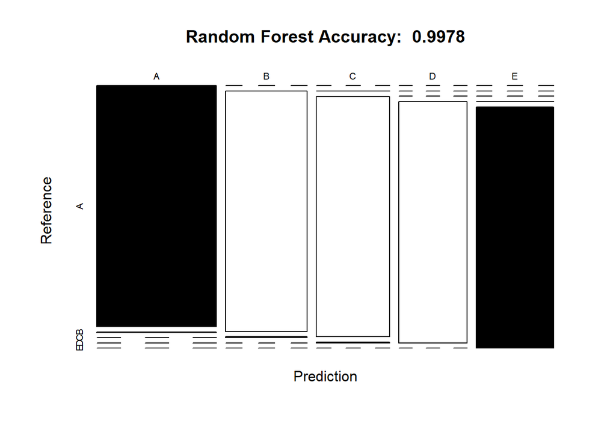

```r
plot(cmRF$table, col = cmRF$byClass,
     main = paste("Random Forest Accuracy: ",
                  round(cmRF$overall['Accuracy'], 4)))
```

We can conclude here that the model has a high overall accuracy and its a very good option to use as a final model but first we have to train another model to compare, so a gbm model is trained.

## Training GBM model

```r
trainControlGBM <- trainControl(method = "repeatedcv", number = 2, repeats = 1)
modGBM  <- train(classe ~ ., data=train_1, method = "gbm",
                    trControl = trainControlGBM, verbose = FALSE)
modGBM$finalModel
```

```
## A gradient boosted model with multinomial loss function.
## 150 iterations were performed.
## There were 53 predictors of which 53 had non-zero influence.
```

```r
predictGBM <- predict(modGBM, newdata=test_1)
cmGBM <- confusionMatrix(predictGBM, test_1$classe)
cmGBM
```

```
## Confusion Matrix and Statistics
##
##           Reference
## Prediction    A    B    C    D    E
##          A 1673    4    0    1    0
##          B    0 1124    5    4    3
##          C    0   10 1017    7    0
##          D    1    1    4  951    6
##          E    0    0    0    1 1073
##
## Overall Statistics
##
##                Accuracy : 0.992
##                  95% CI : (0.9894, 0.9941)
##     No Information Rate : 0.2845
##     P-Value [Acc > NIR] : < 2.2e-16
##
##                   Kappa : 0.9899
##
##  Mcnemar's Test P-Value : NA
##
## Statistics by Class:
##
##                      Class: A Class: B Class: C Class: D Class: E
## Sensitivity            0.9994   0.9868   0.9912   0.9865   0.9917
## Specificity            0.9988   0.9975   0.9965   0.9976   0.9998
## Pos Pred Value         0.9970   0.9894   0.9836   0.9875   0.9991
## Neg Pred Value         0.9998   0.9968   0.9981   0.9974   0.9981
## Prevalence             0.2845   0.1935   0.1743   0.1638   0.1839
## Detection Rate         0.2843   0.1910   0.1728   0.1616   0.1823
## Detection Prevalence   0.2851   0.1930   0.1757   0.1636   0.1825
## Balanced Accuracy      0.9991   0.9922   0.9939   0.9920   0.9957
```

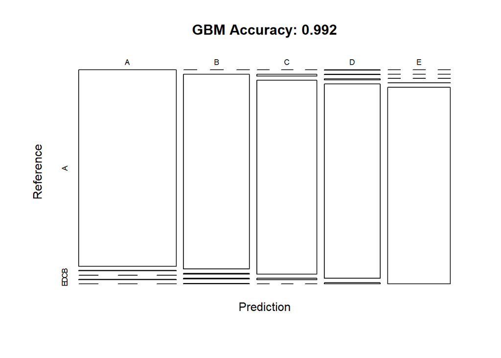

```r
plot(cmGBM$table, col = cmGBM$byClass,
     main = paste("GBM Accuracy:", round(cmGBM$overall['Accuracy'], 4)))
```

We see that gbm has also a really good overall accuracy: 0.992, but random forest y slightly higher: 0.998 so we will use that model to predict the assigment quiz

## Quiz prediction

```r
Quiz <- predict(modRF, newdata=test_0)
Quiz
```

```
##  [1] B A B A A E D B A A B C B A E E A B B B
## Levels: A B C D E
```